# IA para Científicos Sociales

Sesión 2.4: Laboratorio 4 - Regresión y regularización

Danilo Freire

danilofreire@gmail.com

Department of Data and Decision Sciences  
Emory University

# Laboratorio 4: Regresión y regularización

## Objetivos del laboratorio

**Retomamos la clase de regresión.** Hoy ejecutamos paso a paso la misma receta que vimos en la teoría:

1. Preparar los datos con una `receta`
2. Ajustar un baseline OLS
3. Tunear LASSO con validación cruzada
4. Implementar Ridge por analogía (**Ejercicio 1**)
5. Comparar los tres modelos
6. Decidir: ¿predicción o explicación? (**Ejercicio 2**)

**Lo que vamos a aprender:**

- Cuándo y cómo usar regularización
- Diferencias prácticas entre LASSO y Ridge
- Tuning de `penalty` con validación cruzada
- Trade-off entre interpretabilidad y rendimiento

La mayoría de los slides son demostraciones: corremos el código juntos. Solo hay 2 ejercicios, ambos con solución en el apéndice 🤓

# Parte 1: Preparación

## Cargar paquetes y datos

```r
# Si algún paquete falta: install.packages(c("tidymodels", "tidyverse", "glmnet"))
library(tidymodels)  # rsample, parsnip, recipes, workflows, tune, yardstick
library(tidyverse)   # incluye readr (read_csv), dplyr, ggplot2, etc.
library(glmnet)      # motor para LASSO, Ridge, Elastic Net

set.seed(2026)

# Cargar el dataset
datos <- read_csv("datos/latinobarometro_sim.csv", show_col_types = FALSE)
# Lean el archivo directo desde la web:
# datos <- read_csv("https://raw.githubusercontent.com/danilofreire/introduccion-ia-ucu/main/clases/dia-02/datos/latinobarometro_sim.csv", show_col_types = FALSE)

# Convertir categóricas a factor
datos <- datos |>
  mutate(
    pais         = factor(pais),
    zona         = factor(zona),
    genero       = factor(genero),
    uso_internet = factor(uso_internet, levels = c("nunca", "semanal", "diario"))
  )

glimpse(datos)
```

```
Rows: 500
Columns: 14
$ pais                    <fct> Argentina, Costa Rica, Panamá, Perú, Nicaragua…
$ edad                    <dbl> 65, 19, 82, 54, 32, 21, 57, 21, 57, 80, 38, 69…
$ educacion_anios         <dbl> 15, 18, 11, 9, 14, 9, 7, 17, 3, 12, 12, 14, 9,…
$ ingreso_hogar           <dbl> 7, 10, 3, 8, 5, 5, 5, 9, 3, 7, 6, 6, 5, 8, 9, …
$ zona                    <fct> urbana, rural, urbana, urbana, urbana, urbana,…
$ genero                  <fct> hombre, hombre, mujer, mujer, hombre, hombre, …
$ confianza_gobierno      <dbl> 2, 3, 2, 4, 5, 5, 2, 4, 3, 1, 1, 2, 3, 3, 3, 3…
$ confianza_justicia      <dbl> 3, 3, 3, 2, 4, 2, 2, 4, 2, 3, 3, 2, 4, 3, 4, 3…
$ satisfaccion_democracia <dbl> 2, 1, 2, 2, 4, 3, 3, 4, 3, 3, 2, 4, 2, 2, 2, 3…
$ percepcion_economia     <dbl> 3, 5, 5, 5, 2, 5, 4, 2, 3, 3, 4, 4, 4, 1, 2, 4…
$ uso_internet            <fct> semanal, diario, diario, diario, nunca, semana…
$ interes_politica        <dbl> 3, 3, 3, 3, 3, 4, 4, 1, 1, 1, 1, 1, 2, 1, 3, 1…
$ satisfaccion_vida       <dbl> 8.6, 8.3, 5.3, 7.8, 6.3, 8.7, 5.9, 6.4, 4.5, 6…
$ voto                    <chr> "no", "si", "si", "no", "si", "si", "no", "si"…
```

## Dividir los datos

```r
# División train/test (75/25), estratificada por el outcome
# (con una variable numérica, rsample estratifica por cuartiles)
datos_split <- initial_split(datos, prop = 0.75, strata = satisfaccion_vida)
datos_train <- training(datos_split)
datos_test  <- testing(datos_split)

cat("Train:", nrow(datos_train), "obs | Test:", nrow(datos_test), "obs\n")
```

```
Train: 374 obs | Test: 126 obs
```

- La variable objetivo es `satisfaccion_vida` (1-10, continua)
- Train tendrá ~375 obs, test ~125

## Receta de preprocesamiento

```r
# Predecir con todas las variables menos voto (outcome del Lab 3) y pais (alta cardinalidad)
receta <- recipe(satisfaccion_vida ~ ., data = datos_train) |>
  step_rm(pais, voto) |>                       # eliminar variables no predictivas o con demasiados niveles
  step_dummy(all_nominal_predictors()) |>      # categóricas → dummies
  step_normalize(all_numeric_predictors()) |>  # normalizar (importante para regularización)
  step_zv(all_predictors())                    # eliminar varianza cero

# Verificar
# prep() = preparar la receta con los datos de train; juice() = extraer el dataset preprocesado
receta |> prep() |> juice() |> glimpse()
```

```
Rows: 374
Columns: 13
$ edad                    <dbl> 1.56520710, -1.36378561, 0.58887619, -0.798541…
$ educacion_anios         <dbl> -0.01407531, -0.25335565, -0.73191632, -0.7319…
$ ingreso_hogar           <dbl> -1.0474034, -0.6102060, -1.4846008, -0.6102060…
$ confianza_gobierno      <dbl> -0.3354074, 0.7947040, -0.3354074, -0.3354074,…
$ confianza_justicia      <dbl> 0.4016346, 0.4016346, 0.4016346, -1.6420570, 0…
$ satisfaccion_democracia <dbl> -0.5613683, 1.6486502, -0.5613683, 0.5436409, …
$ percepcion_economia     <dbl> 1.6921109, 1.6921109, 0.8287419, 0.8287419, 1.…
$ interes_politica        <dbl> 0.5350528, 1.5457080, -0.4756025, 0.5350528, 0…
$ satisfaccion_vida       <dbl> 5.3, 5.4, 4.3, 5.5, 5.3, 5.4, 4.4, 5.7, 5.5, 5…
$ zona_urbana             <dbl> 0.5621869, 0.5621869, 0.5621869, 0.5621869, -1…
$ genero_mujer            <dbl> 1.0148141, 1.0148141, -0.9827674, 1.0148141, -…
$ uso_internet_semanal    <dbl> -0.6115532, -0.6115532, -0.6115532, -0.6115532…
$ uso_internet_diario     <dbl> 0.8355407, 0.8355407, 0.8355407, 0.8355407, 0.…
```

# Parte 2: OLS baseline

## OLS: spec y ajuste

```r
# Regresión lineal con motor lm
modelo_ols <- linear_reg() |>
  set_engine("lm") |>
  set_mode("regression")

# Workflow + ajuste (combinados en una pipeline)
ajuste_ols <- workflow() |>
  add_recipe(receta) |>
  add_model(modelo_ols) |>
  fit(data = datos_train)

# Coeficientes ordenados por magnitud (top 5)
tidy(ajuste_ols) |>
  arrange(desc(abs(estimate))) |>
  head(5)
```

```
# A tibble: 5 × 5
  term                    estimate std.error statistic   p.value
  <chr>                      <dbl>     <dbl>     <dbl>     <dbl>
1 (Intercept)                6.69     0.0609    110.   1.66e-279
2 confianza_gobierno         0.320    0.0684      4.69 3.96e-  6
3 educacion_anios            0.310    0.0741      4.18 3.61e-  5
4 ingreso_hogar              0.290    0.0742      3.91 1.12e-  4
5 satisfaccion_democracia    0.276    0.0622      4.43 1.23e-  5
```

- `ajuste_ols` ya tiene el modelo ajustado a `datos_train`
- En el próximo slide lo evaluamos en test

## Evaluar OLS en test

```r
# Generar predicciones (augment() añade .pred al test set)
pred_ols <- augment(ajuste_ols, datos_test)

# Calcular métricas en test
metricas_ols <- pred_ols |>
  metrics(truth = satisfaccion_vida, estimate = .pred)

metricas_ols |> knitr::kable(digits = 3)
```

| .metric | .estimator | .estimate |
| --- | --- | --- |
| rmse | standard | 1.286 |
| rsq | standard | 0.225 |
| mae | standard | 1.018 |

- RMSE ≈ 1.3: en promedio la predicción se aleja de la realidad en ~1.3 puntos (escala 1-10)
- R² ≈ 0.23: el modelo explica ~23% de la varianza de la satisfacción

# Parte 3: LASSO con tuning

## Definir LASSO + grilla de búsqueda

```r
# LASSO: linear_reg con mixture = 1 (L1 puro)
# tune() = "este valor se busca con CV"
modelo_lasso <- linear_reg(penalty = tune(), mixture = 1) |>
  set_engine("glmnet") |>
  set_mode("regression")

wf_lasso <- workflow() |> add_recipe(receta) |> add_model(modelo_lasso)

# Grilla de 30 valores de λ en escala logarítmica (10^-4 = 0.0001 a 10^0 = 1)
grilla_lambda <- grid_regular(penalty(range = c(-4, 0)), levels = 30)

head(grilla_lambda)
```

```
# A tibble: 6 × 1
   penalty
     <dbl>
1 0.0001
2 0.000137
3 0.000189
4 0.000259
5 0.000356
6 0.000489
```

- `mixture = 1` → LASSO puro. Si fuera `0`, sería Ridge (lo ven en el Ejercicio 1)
- `tune()` deja `penalty` (λ) pendiente: lo elige la validación cruzada

## Tuning de LASSO con CV

```r
# Crear folds (10-fold CV)
folds <- vfold_cv(datos_train, v = 10)

# Tuning: probar cada valor de la grilla con CV
resultados_lasso <- tune_grid(
  wf_lasso,
  resamples = folds,
  grid      = grilla_lambda,
  metrics   = metric_set(rmse)
)

# Top 5 mejores λ por RMSE
resultados_lasso |>
  collect_metrics() |>
  filter(.metric == "rmse") |>
  arrange(mean) |>
  head(5) |>
  knitr::kable(digits = 4)
```

| penalty | .metric | .estimator | mean | n | std_err | .config |
| --- | --- | --- | --- | --- | --- | --- |
| 0.0161 | rmse | standard | 1.1916 | 10 | 0.0559 | pre0_mod17_post0 |
| 0.0221 | rmse | standard | 1.1916 | 10 | 0.0560 | pre0_mod18_post0 |
| 0.0117 | rmse | standard | 1.1920 | 10 | 0.0559 | pre0_mod16_post0 |
| 0.0085 | rmse | standard | 1.1924 | 10 | 0.0559 | pre0_mod15_post0 |
| 0.0062 | rmse | standard | 1.1927 | 10 | 0.0559 | pre0_mod14_post0 |

- `mean` es el RMSE promedio sobre los 10 folds; `std_err` indica cuánto varía entre folds

## Visualizar el tuning de LASSO

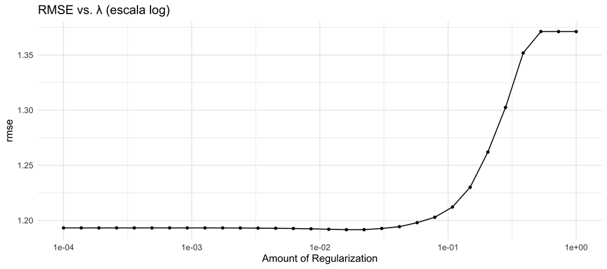

```r
autoplot(resultados_lasso) +
  scale_x_log10() +
  theme_minimal() +
  labs(title = "RMSE vs. λ (escala log)")
```

- La curva suele tener forma de **U**: λ muy bajo → poca regularización (sobreajuste); λ muy alto → demasiada (subajuste)
- El mínimo de la curva es el λ óptimo según CV

## Seleccionar λ y ajuste final

```r
# 1. Seleccionar el λ con menor RMSE
lambda_min <- select_best(resultados_lasso, metric = "rmse")

# 2. Finalizar el workflow con ese λ y ajustar a todo el train
ajuste_lasso <- wf_lasso |>
  finalize_workflow(lambda_min) |>
  fit(data = datos_train)

# Métricas en test (las reutilizamos en la tabla comparativa)
pred_lasso     <- augment(ajuste_lasso, datos_test)
metricas_lasso <- pred_lasso |>
  metrics(truth = satisfaccion_vida, estimate = .pred)

# 3. Coeficientes y conteo de variables eliminadas
coef_lasso <- tidy(ajuste_lasso) |>
  filter(term != "(Intercept)") |>
  arrange(desc(abs(estimate)))

cat("Variables eliminadas (coef = 0):",
    sum(coef_lasso$estimate == 0), "de", nrow(coef_lasso), "\n")
```

```
Variables eliminadas (coef = 0): 1 de 12
```

```r
coef_lasso |> head(8) |> knitr::kable(digits = 3)
```

| term | estimate | penalty |
| --- | --- | --- |
| confianza_gobierno | 0.307 | 0.016 |
| educacion_anios | 0.302 | 0.016 |
| ingreso_hogar | 0.277 | 0.016 |
| satisfaccion_democracia | 0.260 | 0.016 |
| percepcion_economia | 0.227 | 0.016 |
| edad | 0.129 | 0.016 |
| zona_urbana | -0.063 | 0.016 |
| interes_politica | 0.057 | 0.016 |

## Comparar coeficientes OLS vs. LASSO

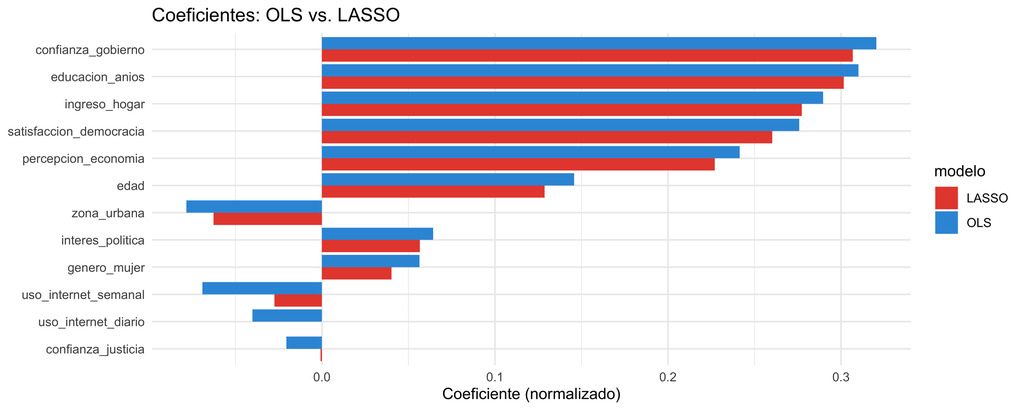

```r
coef_ols  <- tidy(ajuste_ols)   |> filter(term != "(Intercept)") |> select(term, OLS   = estimate)
coef_lasc <- tidy(ajuste_lasso) |> filter(term != "(Intercept)") |> select(term, LASSO = estimate)

left_join(coef_ols, coef_lasc, by = "term") |>
  pivot_longer(c(OLS, LASSO), names_to = "modelo", values_to = "coef") |>
  ggplot(aes(x = reorder(term, abs(coef)), y = coef, fill = modelo)) +
  geom_col(position = "dodge") + coord_flip() +
  scale_fill_manual(values = c("OLS" = "#3498DB", "LASSO" = "#E74C3C")) +
  labs(title = "Coeficientes: OLS vs. LASSO",
       x = NULL, y = "Coeficiente (normalizado)") +
  theme_minimal()
```

- Es la versión práctica de “interpretar los coeficientes de LASSO” que vimos en la clase: LASSO encoge coeficientes hacia cero (algunos exactamente cero); OLS los deja todos sin restricción

# Parte 4: Ridge por analogía

## Ejercicio 1: Implementar Ridge por analogía

**Tarea (5 min):** adapten el pipeline de LASSO que acabamos de ver. Cambien solo lo necesario para Ridge: completen los tres huecos

```r
# 1. Modelo Ridge: igual que LASSO pero mixture = 0
modelo_ridge <- linear_reg(penalty = tune(), mixture = ___) |>  # TODO: ¿qué valor?
  set_engine("glmnet") |>
  set_mode("regression")

# 2. Workflow + tuning (reutilizamos folds y grilla_lambda)
wf_ridge <- workflow() |> add_recipe(receta) |> add_model(modelo_ridge)

resultados_ridge <- tune_grid(
  ___, resamples = folds, grid = grilla_lambda,    # TODO: ¿qué workflow?
  metrics = metric_set(rmse)
)

# 3. Seleccionar mejor λ, finalizar, ajustar
lambda_ridge <- select_best(___, metric = "rmse")  # TODO: ¿qué resultados?
ajuste_ridge <- finalize_workflow(wf_ridge, lambda_ridge) |>
  fit(data = datos_train)

# 4. Evaluar en test
pred_ridge     <- augment(ajuste_ridge, datos_test)
metricas_ridge <- pred_ridge |>
  metrics(truth = satisfaccion_vida, estimate = .pred)

# 5. Contar variables eliminadas (debería ser 0!)
cat("Variables eliminadas en Ridge:",
    sum(tidy(ajuste_ridge)$estimate[-1] == 0), "\n")
metricas_ridge
```

**Nota**

**Pista**: el único cambio conceptual respecto a LASSO es `mixture = 0`. Los objetos `folds` y `grilla_lambda` ya están definidos; reutilícenlos tal cual

**Tip**

**Checkpoint**: Ridge debería eliminar **0 variables** (puede mostrar valores como `1e-10`, prácticamente cero pero no exactos). RMSE similar a LASSO (~1.1-1.3)

Apéndice 1: Solución

## LASSO selecciona, Ridge encoge

**LASSO (L1)**

- Penaliza la suma de valores absolutos
- Reduce algunos coeficientes a exactamente cero
- Hace selección automática de variables
- Útil cuando solo algunas variables importan

**Ridge (L2)**

- Penaliza la suma de cuadrados
- Reduce todos los coeficientes pero ninguno a cero exacto
- Mantiene todas las variables
- Útil con variables correlacionadas (multicolinealidad)

Geométricamente: la “bola” de L1 tiene esquinas que tocan los ejes (coeficiente = 0); la “bola” de L2 es lisa y nunca toca exactamente un eje.

Para una versión intermedia (Elastic Net), ver Apéndice 5

# Parte 5: Comparación final

## Tabla comparativa: OLS, LASSO y Ridge

```r
# Combinar las métricas de los 3 modelos (ya creadas en los slides anteriores)
tabla_final <- bind_rows(
  metricas_ols   |> mutate(modelo = "OLS"),
  metricas_lasso |> mutate(modelo = "LASSO"),
  metricas_ridge |> mutate(modelo = "Ridge")
) |>
  select(modelo, .metric, .estimate) |>
  pivot_wider(names_from = .metric, values_from = .estimate) |>
  arrange(rmse)

tabla_final |> knitr::kable(digits = 3)
```

| modelo | rmse | rsq | mae |
| --- | --- | --- | --- |
| Ridge | 1.281 | 0.229 | 1.012 |
| LASSO | 1.283 | 0.226 | 1.016 |
| OLS | 1.286 | 0.225 | 1.018 |

- Los 3 modelos producen RMSE muy similares en este dataset
- LASSO selecciona variables; Ridge las encoge; OLS no penaliza

## Ejercicio 2: ¿Predicción o explicación?

**Tarea (5 min):** miren la tabla comparativa y el gráfico de coeficientes OLS vs. LASSO, y discutan en grupo

1. ¿Qué variables redujo LASSO a cero? ¿Tiene sentido sustantivo que esas pesen menos?
2. Si el objetivo es explicar qué determina la satisfacción con la vida, ¿qué modelo prefieren? ¿Y si solo quieren predecirla para casos nuevos?
3. ¿Por qué las diferencias de RMSE entre los tres modelos son tan pequeñas con estos datos?

**Nota**

**Pista**: vuelvan a la distinción de la clase entre predicción y explicación. Un modelo más simple (menos variables) es más fácil de explicar, aunque prediga casi igual

Apéndice 2: Discusión

# Cierre

## Discusión y resumen

**Lo que vimos hoy:**

1. Ejecutar la receta completa: `receta` → modelo → `workflow`
2. Tunear LASSO con CV y seleccionar λ
3. Implementar Ridge por analogía (Ejercicio 1)
4. Comparar OLS, LASSO y Ridge
5. Decidir entre predicción y explicación (Ejercicio 2)

**Conceptos clave:**

- `mixture = 1` → LASSO (selecciona)
- `mixture = 0` → Ridge (encoge)
- `tune()` + `tune_grid()` para CV
- `select_best()` + `finalize_workflow()` para fijar λ
- En este dataset las diferencias entre OLS/LASSO/Ridge son marginales

¿Por qué tan marginales? Porque las relaciones son aproximadamente lineales y el ratio n/p no es extremo. La regularización brilla cuando p ≫ n o hay colinealidad fuerte.

Para llevarse a casa: en el Apéndice 4 apliquen todo el pipeline a un outcome diferente (`satisfaccion_democracia`)

# Apéndice: Soluciones

## Apéndice 1: Solución Ejercicio 1

```r
# Cambio único: mixture = 0 (Ridge en vez de LASSO)
modelo_ridge <- linear_reg(penalty = tune(), mixture = 0) |>
  set_engine("glmnet") |>
  set_mode("regression")

wf_ridge <- workflow() |> add_recipe(receta) |> add_model(modelo_ridge)

resultados_ridge <- tune_grid(
  wf_ridge, resamples = folds, grid = grilla_lambda,
  metrics = metric_set(rmse)
)

lambda_ridge <- select_best(resultados_ridge, metric = "rmse")
ajuste_ridge <- finalize_workflow(wf_ridge, lambda_ridge) |>
  fit(data = datos_train)

pred_ridge     <- augment(ajuste_ridge, datos_test)
metricas_ridge <- pred_ridge |>
  metrics(truth = satisfaccion_vida, estimate = .pred)

cat("Variables eliminadas en Ridge:",
    sum(tidy(ajuste_ridge)$estimate[-1] == 0), "\n")
metricas_ridge
```

**Métricas de Ridge en test:**

| .metric | .estimator | .estimate |
| --- | --- | --- |
| rmse | standard | 1.281 |
| rsq | standard | 0.229 |
| mae | standard | 1.012 |

- Ridge nunca elimina variables, solo las encoge; el conteo de eliminadas es 0
- RMSE similar al de LASSO en este dataset

Volver al ejercicio

## Apéndice 2: Discusión Ejercicio 2

Volver al ejercicio

## Apéndice 3: Dos criterios para elegir λ (opcional)

En la clase vimos dos formas de elegir λ. Hasta ahora usamos `select_best` (mínimo RMSE). La regla 1-SE elige el λ más grande (modelo más simple) que queda a menos de un error estándar del mínimo:

```r
# Criterio 1: mínimo RMSE (el que usamos en el lab)
lambda_min  <- select_best(resultados_lasso, metric = "rmse")

# Criterio 2: regla de un error estándar (modelo más parsimonioso)
lambda_1se  <- select_by_one_std_err(resultados_lasso, metric = "rmse", desc(penalty))

bind_rows(
  lambda_min |> mutate(criterio = "min"),
  lambda_1se |> mutate(criterio = "1-SE")
)
```

- `lambda_1se` suele ser mayor, así que regulariza más y deja menos variables
- Sacrifica un poco de RMSE a cambio de un modelo más simple de explicar

Volver a la sección de discusión

## Apéndice 4: Capstone: outcome diferente (opcional)

**Para llevarse a casa:** apliquen todo el pipeline a `satisfaccion_democracia` (escala 1-5). ¿Cómo cambian los resultados?

```r
# 1. Nueva receta para predecir satisfaccion_democracia
receta_dem <- recipe(satisfaccion_democracia ~ ., data = datos_train) |>
  step_rm(pais, voto, satisfaccion_vida) |>      # excluir outcomes ajenos
  step_dummy(all_nominal_predictors()) |>
  step_normalize(all_numeric_predictors()) |>
  step_zv(all_predictors())

# 2. LASSO con la nueva receta (mismo patrón)
wf_lasso_dem <- workflow() |> add_recipe(receta_dem) |> add_model(modelo_lasso)

resultados_dem <- tune_grid(
  wf_lasso_dem, resamples = folds, grid = grilla_lambda,
  metrics = metric_set(rmse)
)

lambda_dem  <- select_best(resultados_dem, metric = "rmse")
ajuste_dem  <- finalize_workflow(wf_lasso_dem, lambda_dem) |>
  fit(data = datos_train)

# 3. Evaluación
pred_dem <- augment(ajuste_dem, datos_test)

pred_dem |> metrics(truth = satisfaccion_democracia, estimate = .pred)
```

Preguntas para reflexionar:

- ¿Las mismas variables son predictivas, o cambian?
- ¿El RMSE es mayor o menor que para `satisfaccion_vida`?
- Pueden repetir con `percepcion_economia` como tercer outcome

Volver a la sección de discusión

## Apéndice 5: Elastic Net (opcional)

Elastic Net combina LASSO y Ridge: `mixture` entre 0 y 1

```r
# Ajustar AMBOS hiperparámetros: penalty (λ) y mixture (α)
modelo_enet <- linear_reg(penalty = tune(), mixture = tune()) |>
  set_engine("glmnet") |>
  set_mode("regression")

wf_enet <- workflow() |> add_recipe(receta) |> add_model(modelo_enet)

# Grilla 2D: 20 valores de λ × 5 de mixture (como en la clase)
grilla_enet <- grid_regular(
  penalty(range = c(-4, 0)),
  mixture(range = c(0, 1)),
  levels = c(20, 5)
)

resultados_enet <- tune_grid(
  wf_enet, resamples = folds, grid = grilla_enet,
  metrics = metric_set(rmse)
)

mejor_enet  <- select_best(resultados_enet, metric = "rmse")
mejor_enet  # vean el mixture óptimo

ajuste_enet <- finalize_workflow(wf_enet, mejor_enet) |>
  fit(data = datos_train)

predict(ajuste_enet, datos_test) |>
  bind_cols(datos_test |> select(satisfaccion_vida)) |>
  metrics(truth = satisfaccion_vida, estimate = .pred)
```

- Si `mixture` óptimo está cerca de 1 → LASSO ganó
- Si está cerca de 0 → Ridge ganó
- Si intermedio → Elastic Net mejora sobre ambos

Volver a la sección de LASSO vs. Ridge

# ¡Fin del Día 2! 🤓